# Biological control of weeds in Australia: the last 120 years - Cullen - 2023 - Austral Entomology - Wiley Online Library

[Austral Entomology](https://onlinelibrary.wiley.com/journal/20521758)

[Volume 62, Issue 2](https://onlinelibrary.wiley.com/toc/20521758/2023/62/2) p. 133-148

[figure not shown]

REVIEW

Open Access

# Biological control of weeds in Australia: the last 120 years

[J. M. Cullen](https://onlinelibrary.wiley.com/authored-by/ContribAuthorRaw/Cullen/J.+M.),

[W. A. Palmer](https://onlinelibrary.wiley.com/authored-by/ContribAuthorRaw/Palmer/W.+A.),

[A. W. Sheppard](https://onlinelibrary.wiley.com/authored-by/ContribAuthorRaw/Sheppard/A.+W.),

First published: 27 March 2023

https://doi.org/10.1111/aen.12638

## Abstract

The development of the field of biological control of weeds in Australia is described, from the first attempts in 1903 to the present day. The interest sparked by the obvious success of prickly pear program, apparent from 1930 to 1935, resulted in several programs during the next 20 years, followed by a decline in activity until the 1970s when activity increased enormously following the success of the skeleton weed program and the effective use of a plant pathogen for the first time. This momentum was maintained until the beginning of the present century with several successes and was marked by several important advances in genetic profiling, host-specificity testing, economic evaluation, conflict of interest resolution and the ecology of insect/plant interactions, including evaluation of the effectiveness of individual introductions. Biological control has proved to be a valuable and effective approach to weed management in Australia with 39% of all programs considered to produce complete or near-complete control, 30.5% partial control and an average benefit–cost ratio of 23:1. Funding for research has been variable with a decline from the late 1990s but with a significant increase again since 2020.

## INTRODUCTION

Geographic isolation from the evolution of plants and animals in other parts of the world for approximately 200 million years has left Australian environments, both native and agricultural, vulnerable to invasion by species from elsewhere without the complex of coevolved species characteristic of their original habitats (Morton et al. 2014). Many invasive plant species, whether introduced deliberately or accidentally, have colonised large areas of the continent, disrupted native ecosystems, damaged agricultural production and choked waterways (Groves 2011; Sindel 2000). In agriculture alone, the annual costs of these exotic species plus a small number of native species are in excess of $7.1 billion (2020 dollars) in production losses, control costs and research costs in cropping and livestock agriculture and in weed control on public and indigenous lands (Llewellyn et al. 2016; Sinden et al. 2004). Indirect costs to the environment and aquatic systems are more difficult to quantify but are expected to be of similar magnitude in impacts on threatened and endangered species and communities and many ecosystem services, plus societal and amenity costs and the costs of attempted control (Groves 2011). It is therefore not surprising that Australia has a long history of biological control of invasive exotic species, dating back to 1903, importing key host-specific species in the complex of natural enemies originally associated with these species in their region of origin in an effort to reduce their impact in Australia (Julien et al. 2012; Wilson 1960).

The first major program in Australia, against prickly pear *Opuntia stricta* (Haw.) Haw., was a spectacular success, initiating a legacy of activity in the field. Australia has now initiated 88 (Julien et al. 2012; L. Morin personal communication, July 1, 2017) and completed 58 agricultural and environmental weed biological control programs and become a pioneer in the successful use of plant pathogens for weed biocontrol. Particularly since 1970, a more research-oriented approach plus the development of new technologies and changes in social attitudes have influenced and encouraged the development of several other initiatives in both theory and practice that have improved the approach in Australia and elsewhere. Since the reviews of Briese (2004) and Palmer et al. (2010), a comprehensive description of all Australian programs has been published (Julien et al. 2012). Here, we draw on the more detailed information of the 2012 compilation and expand on and update the history of the development of the changes in theory and practice in Australia reviewed by Briese (2004) and their impact on the discipline.

## THE AUSTRALIAN SCENE

Almost all Australian habitats have been invaded by exotic weeds, whether from Europe and South Africa in temperate regions, from North, Central and South America in subtropical and tropical regions or increasingly from Asia (Groves 1997). Understandably, most of the economic data come from agriculture, with Sinden et al. (2004) estimating the loss to Australian agriculture in the range of $3.4–4.4 billion per annum, while noting that losses from reduced production were not available for several industries. Sinden et al. (2004) estimated the costs of control in natural environments as $20 million per annum, on other public land at $81 million per annum and on indigenous land at $3 million per annum, but these do not include any losses from environmental degradation or social impacts including on cultural values. The authors concluded that an overall conservative estimate would be between $3.554 billion and $4.532 billion per annum. Llewellyn et al. (2016) estimated the total cost of weeds (revenue loss plus control expenditure) to Australian grain growers at $3.318 billion or $146/ha, causing annual yield losses of 2.76 million tonnes of grain. Estimated annual yield losses due to weed competition from residual in-crop weeds were $278 million and $430 million from weeds in fallows, with $187 million in additional herbicide costs due to increasing herbicide resistance (Llewellyn et al. 2016). When combining and converting the totals in both reviews to 2020 dollars (using Reserve Bank of Australia inflation calculator of 1.45*x*), an overall conservative estimate of the total cost of weeds to Australia would be between $6.420 billion and $7.768 billion per annum or approximately $7.1 billion per annum.

Concern over impacts in areas other than agriculture and appropriate estimates of cost have been relatively recent developments in determining priorities in allocation of resources for control, and for many years, biological control was only targeted at weeds of agricultural importance (Wilson 1960). Although it was always an added bonus if control of an agricultural weed also reduced any environmental impact, it was not until 1984 that a weed solely of environmental concern, bitou bush/boneseed (*Chrysanthemoides monilifera* (L.) T. Norl.), was targeted for biological control. Since then, the Australian Weeds Strategy has been developed, updated in 2016 (Invasive Plants and Animals Committee 2016), with a prioritisation process and the declaration of Weeds of National Significance (Department of Agriculture, Fisheries and Forestry 2012). This was the first process in Australia of prioritising widespread weeds at the national level from a governmental perspective, taking into account all impacts and the difficulties of control in sensitive environments.

## THE HISTORY OF BIOLOGICAL CONTROL IN AUSTRALIA

The first deliberate introduction of a natural enemy of a weed in Australia was in 1903 when the Queensland Department of Agriculture and Stock (QDAS) introduced the monacantha cochineal *Dactylopius ceylonicus* (Green) for control of *Opuntia monacantha* (Willd.) Haw. (Wilson 1960, 1964). This culture died before releases were made, but better results were obtained with the importation of three *Dactylopius* spp., the moth *Cactoblastis cactorum* (Bergroth) and a disease of *Opuntia* in 1913–1914, resulting very quickly in the successful control of *O. monacantha* by the *Dactylopius* spp. (Wilson 1960). Four agents were also released against lantana, *Lantana camara* L. in 1914, but were unsuccessful (Wilson 1960). Serious activity really started after World War I with the establishment of the Commonwealth Prickly Pear Board in 1920 (Dodd 1940). By 1925, approximately 25 million hectares were infested by prickly pear, with at least half of that rendered completely useless. From 1921 to 1940, 19 insect species were released and 12 established against the various *Opuntia* spp. The most effective agent against *O. stricta* (Haw.) Haw. is generally accepted as having been the moth *C. cactorum*, aided by bacterial and fungal soft rots that gain entry via the feeding damage of the larvae (Dodd 1940; Hatcher & Paul 2001; Martin & Dale 2001), but this has recently been challenged by comparison with the situation in South Africa (Hoffmann et al. 2020), which gives more credit to *Dactylopius opuntiae* (Cockerell). This species is certainly more effective where *C. cactorum* cannot complete two generations per annum or possibly where *O. stricta* grows in very dry conditions, but *C. cactorum* is still seen as the more important agent in most areas (Hosking 2012; J. R. Hosking personal communication, July 1, 2020). The prickly pear bug *Chelinidea tabulata* (Burmeister) and the spider mite *Tetranychus opuntiae* Banks were also credited with producing significant damage prior to the major destruction produced by *C. cactorum* (Dodd 1940).

Once the potential of *C. cactorum* had been realised, a massive program of field collection and redistribution of the egg sticks was carried out (Raghu & Walton 2007). Most of the original stands of *O. stricta* were destroyed by 1930–1932, but subsequently, lack of host plants caused a significant reduction of *C. cactorum* and hence regrowth of the *Opuntia* spp. during 1933 (Dodd 1940). However, *C. cactorum* increased again in 1933–1935 and the weed declined again; populations became relatively stable thereafter, thus exhibiting the classic initial oscillation of host and natural enemy prior to relative stability at a reduced level (Dodd 1940; Wilson 1960). The program resulted in complete control of prickly pear over 25 million hectares of eastern Australia, predominantly by *C. cactorum* and *D. opuntiae* (Dodd 1940; Hosking 2012; Wilson 1960). This spectacular success at a time when the prickly pear problem was so devastating left a lasting impression on landholders and other stakeholders such that biological control continued to be strongly supported by the community and elected representatives over the decades to come.

When the Commonwealth Prickly Pear Board ceased in 1939, the remaining responsibilities were transferred to the Queensland Department of Public Lands, the NSW Prickly Pear Destruction Commission and then the CSIR Division of Economic Entomology (Dodd 1940). The CSIR Division of Economic Entomology was established in 1927, and in view of the prospects of the prickly pear program, one of its four initial priorities was to investigate further possibilities for control of weeds using imported insect agents. Queensland continued to be responsible for the program on lantana (from 1914) and in consultation with CSIR commenced a program on crofton weed (*Ageratina adenophora* (Spreng.) King & Robinson) from 1952, whereas CSIR (later CSIRO) was responsible for programs on Noogoora burr (*Xanthium occidentale* Bertol.), St John's wort (*Hypericum perforatum* L.) and ragwort (*Jacobaea vulgaris* Gaertn.) (all from 1929) (Wilson 1960). The Tasmanian Department of Agriculture introduced the gorse seed weevil (*Exapion ulicis* (Forster)) in 1939 (Wilson 1960). These programs resulted in reasonable success against crofton weed and some success against St John's wort, but no significant reductions in the other weeds (Wilson 1960).

By the 1960s, the work on ragwort was finishing, and apart from some redistribution of agents for *Opuntia* spp. and St John's wort, the only remaining active programs were on lantana and to a limited extent on Noogoora burr (van Klinken & Julien 2003) and Harrisia cactus (*Harrisia* spp.), whereas Queensland started a new program on groundsel bush (*Baccharis halimifolia* L.) in 1962 and CSIRO commenced work on skeleton weed (*Chondrilla juncea* L.) in 1965 (Julien et al. 2012).

The whole field was reinvigorated during the 1970s following the success of the program against skeleton weed (Figure 1). In 1965, CSIRO received funding from the Wheat Industry Research Council to start work on management options for skeleton weed. CSIRO Entomology and CSIRO Plant Industry combined efforts to initiate European research activities in 1966 at the CNRS Ecology Laboratory in Montpellier, France. This was Australia's first investment in an overseas facility to support weed biological control research in the native range of the target weed. CSIRO subsequently rented separate premises before building new facilities in the early 1990s (Sheppard et al. 2008). The success of the skeleton weed program (Burdon et al. 1981; Cullen 1978; Cullen et al. 1973), the fact that it was achieved by the deliberate introduction of a plant pathogen, the biotrophic rust (*Puccinia chondrillina*) Bubàk & Syd., and the demonstrated economic benefits (Marsden et al. 1980) created a favourable environment for reinvestment in the field. CSIRO further developed a program on aquatic weeds with the setting up of a series of overseas laboratories in South America, targeted other weeds of European origin and investigated possibilities for weeds of South African origin, setting up laboratories in Pretoria and then Cape Town. Queensland expanded its operations to include prickly acacia (*Vachellia nilotica* subsp. *indica* (Benth.) Kyal. & Boatwr.), Harrisia cactus (*Harrisia martini* (Labour.) Britton), giant sensitive weed *Mimosa diplotricha* C. Wright, rubber vine (*Cryptostegia grandiflora* (Roxb.) R. Br.) and parthenium (*Parthenium hysterophorus* L.). The Victorian Department of Lands also committed significantly to temperate weeds research including working directly out of the CSIRO Montpellier facility, whereas there were significant contributions from New South Wales, the Northern Territory and Tasmania. The 1980s and 1990s became a period of intense activity with further programs initiated by Queensland and CSIRO (Julien et al. 2012; Winston et al. 2014, updated in 2022) illustrated by the timescale of specific agent releases (Figure 1).

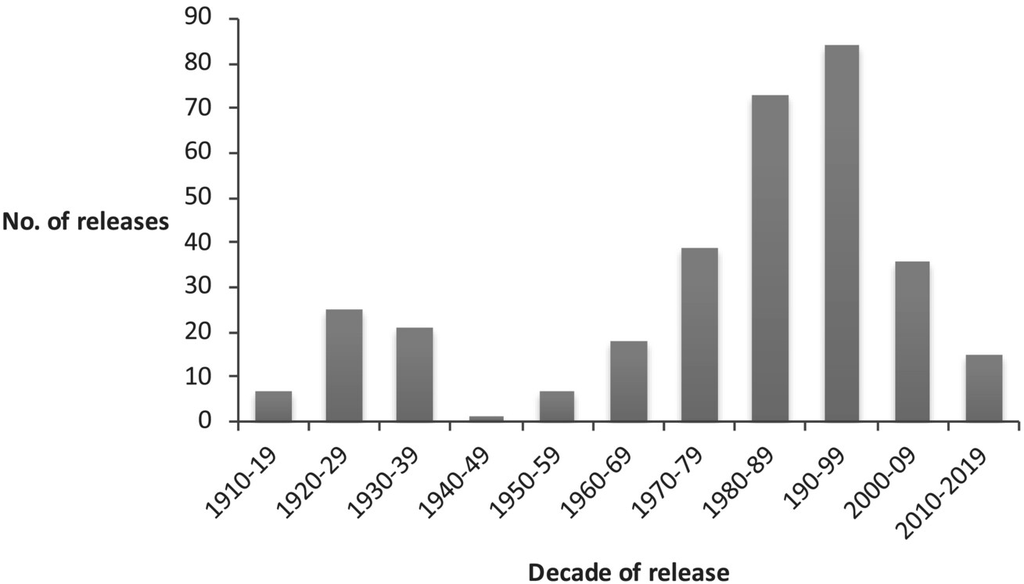

**FIGURE 1**

Number of weed biological control agent releases per decade (known deliberate releases only).

The rate of release of new agents peaked in the 1990s and declined significantly after 2000 (Figure 1). Overall national capacity also declined, gradually in the late 1990s and more significantly since 2000 (Briese 2004), from a peak of 33 scientist FTEs in the early 1990s to only 7.5 in 2013 (Palmer et al. 2014; Zalucki 2015). The 2015 Agricultural Competitiveness White Paper, the 2017 independent review of the intergovernmental agreement on biosecurity and the 5-year review National Environmental Biosecurity Response Agreement in the same year lead to the establishment of the office of Chief Environmental Biosecurity Officer in the Australian Government Department of Agriculture, Water and the Environment in 2017 with a federal budget for the management of established pests and weeds to support State funding. Since then, there has been significant rebuilding of national weed biological control capability close to the levels it was in the early 1990s. As a result, there has been a recent increase in activity again with another 25 agents with permission to release, applications to release or under testing in 2020–2022 (but too recent to impact on Figure 1).

The first review of Australian weed biological control programs in 1960 covered 10 programs and 35 agents released (Wilson 1960). Following the review by Briese (2004), covering much of the improvements in methodology as applied to arthropod agents, and an update of projects in the review by Palmer et al. (2010), Julien et al. (2012) published a comprehensive description by program up till 2010, listing 73 programs on weed species or species groups with 242 agents released. The most recent fifth edition of the World Catalogue of Agents and their Target Weeds (Winston et al. 2014) covers work up to and including December 2012 and lists 272 spp. of agents released on 63 weed species.

## COOPERATIVE RESEARCH CENTRES (CRCs)

Biological control of weeds in Australia benefited significantly from the Australian Government's Cooperative Research Centre Program set up to support multi-agency research hubs. The CRC for Tropical Pest Management (1991–1998), followed by the CRC for Weed Management Systems (1995–2001) and the CRC for Australian Weed Management (2001–2008) supported under the competitive CRC program were invaluable in maintaining national capability and funding for research, specialist workshops and distribution and evaluation of agents. New programs were initiated along with education and training through PhD grants and post-doctoral fellowships (Palmer et al. 2010). However, this additional support was taken to justify some decrease in core support, and given that CRCs were of limited life, their existence did not prevent the long-term decline of support and capability.

## IMPROVEMENTS IN RESEARCH AND DEVELOPMENT

Although the fundamental principle of using host-specific natural enemies to control exotic pest species has not changed, there has been a steady development of research approaches in Australia by which this has been achieved, particularly during the 1970–2000 period.

### Refining the aim of a program

From the 1980s, the weed biological control programs started to be considered as part of an integrated weed management (IWM) approach. The St John's wort biological control program was the first as it had already been demonstrated that pasture management could be effective at suppressing the weed following initial destruction by the leaf beetle *Chrysolina* spp. (Wilson 1943). Increased recognition of environmental impacts with the *Wildlife Protection Act 1982* led to a greater emphasis on environmental weeds and their management in complex and dynamic natural communities. Similarly, improved ecological knowledge of biological control systems encouraged a more critical appraisal of the aim of each program (Briese 2000, 2004; McFadyen 1998; Morin et al. 2009; van Klinken et al. 2016; Wapshere et al. 1989). Some biological control programs were deliberately aimed at reducing weed spread through reduction in seed or propagule production. Others aimed to prevent reinvasion following manual removal (e.g., *Mimosa pigra* L., a large woody shrub, for which destruction of large existing stands is only possible by physical destruction or by fire) (Lonsdale & Miller 1993; Paynter & Flanagan 2004). But most programs were still aimed at widespread control, either on their own or through integration with other control options, leading to agricultural or environmental benefits (Morin et al. 2009). Widespread control generally means reduction in density (e.g., for skeleton weed) where crop losses are directly proportional to weed density. In many cases, however, reduction of weed biomass or cover may be more critical than density (Douglas et al. 2001). In the Scotch broom (*Cytisus scoparius* (L.) Link) biological control program, a weed of national parks, it was estimated that a reduction to 30% cover or less would allow native vegetation to regenerate (J. R. Hosking personal communication, July 1, 1992). The existence of other plant species competitive with the weed needs to be considered as they can act synergistically with an agent in producing control (Groves & Williams 1975; Shabbir, Dhileepan, Zalucki, Khan, & Adkins 2020). Knowledge of the role and timing of nutrient levels and seasonal flushing of billabongs was critical in developing an integrated program for control of the floating fern salvinia (*Salvinia molesta* D. S. Mitchell) in Kakadu National Park using the weevil *Cyrtobagous salviniae* Calder & Sands and judicious use of herbicide (Julien & Storrs 1996; Storrs & Julien 1996).

### Host specificity

Ensuring that an introduced agent does not harm non-target species has been a fundamental aim of biological control of weeds since its inception. However, for many years, only economically important plants were considered for experimental host-specificity testing of potential agents. Possible direct non-target impacts on Australian native species were first considered in the 1970s, initially for pathogens in the skeleton weed program and then increasingly for insects in all programs. This was well before environmental protection legislation came into force in the 1980s under the *Wildlife Protection Act 1982*. Although the basic non-target species testing methodology remained, the choice of test species became more science based, starting from Wapshere's (1974a) advocacy of ‘centrifugal phylogenetic testing’. Analysis of biocontrol risk has since become more sophisticated, with more discussion on the likely behaviour of an agent in the field compared with in the laboratory (Briese 2000, 2004, 2005; Cullen 1990; Sheppard et al. 2005; van Klinken 2000; Withers et al. 1999). This consideration stimulated more experimentation to simulate field situations and more informed debate over relative risks and benefits (Briese 1999; Briese et al. 1995; Briese, Zapater, et al. 2002; Cullen 1990). Briese (2003) proposed refining the classic centrifugal phylogenetic testing principle in the light of modern phylogenetic taxonomic approaches, to eliminate much of Wapshere's ‘safeguard criteria’ involving species unrelated to the target weed. Briese and Walker (2002) described the application of this approach to a specific case, and Briese (2004) stressed the need to work with the regulating and conservation agencies with innately and legislatively conservative standpoints.

Increased international concerns about non-target impacts of weed biological control agents, stimulated by a paper in *Science* (Louda et al. 1997), led to post hoc reviews of the possibility of such impacts from historical programs in Australia (Willis et al. 2003) and reviews of testing protocols in the context of the potential for false negative results (Sheppard et al. 2005). A recent analysis has suggested that direct non-target impacts in Australia are generally low and lower than in any other country given the number of biocontrol agents released (Hinz et al. 2019).

Despite the complex and time-consuming nature of demonstrating safety for introduction, Australia remains one of the few countries with a relatively efficient regulatory process to support biological control programs. Release applications in the United States, for example, currently take 5–10 years to be approved, compared with average 2-year time frames in Australia, and in the United States, plant pathogens are effectively no longer considered for weed biological control (T. Widmer personal communication, June 14, 2022).

### Agent selection

#### Matching the weed and its original environment

#### Taxonomy and genetics

The importance of correct taxonomy was highlighted in the very successful salvinia program, where defining the target species and hence the correct native range (Forno & Harley 1979) allowed the discovery of the appropriate and very effective species of the weevil genus *Cyrtobagous* (Julien 2012; Sands 1983). At the sub-specific level, the skeleton weed program also demonstrated the importance of finding a strain of the rust *P. chondrillina* and a population of the eriophyid mite *Aceria chondrillae* Canestrini effective against the genotype of the weed most important in Australia (Cullen 2012). For rubber vine, accessions of the rust *Maravalia cryptostegiae* (Cummins) collected from *Cryptostegia madagascariensis* (Bojer) ex Decne and *C. grandiflora* Roxb. R. Br. performed similarly in the laboratory, but only accessions collected from *C. grandiflora* were effective in the field. Later work in the skeleton weed program, to try to find other rust strains effective against the other forms of the weed, instigated a photoelectrophoretic analysis of many of the forms of skeleton weed in its native range (Chaboudez 1989; Chaboudez et al. 1992), the first use of genetic differentiation to define sub-specific variation in the target weed in biological control. With advances in genetic technologies, DNA analysis to generate phylogenetic trees to understand target genotype and hence agent matching has been used for several species, for example, blackberry *Rubus fruticosus* L. Agg. (Evans et al. 1998), *Onopordum* thistles (O'Hanlon et al. 2000) and fireweed *Senecio madagascariensis* Poir (Radford et al. 2000), and has now become a standard practice in programs (Goolsby et al. 2006; Morin 2020). Phylogenetic trees have also become a standard for selecting test plant species for host-specificity testing (Briese 1996).

Genetic analyses have supported the understanding of not only the origin of the actual form of a target weed but also the centre of genetic diversity of the weed as a source of possible effective agents where identical forms had not been found (Goolsby et al. 2006; Wapshere 1974b; Wapshere et al. 1989). The establishment of a base for exploration in Iran in the 1980s, in the eastern distribution of *C. juncea* and *Heliotropium europaeum* L., followed later by the establishment of trap gardens of *C. juncea* in Turkey in the 1990s for additional strains of *P. chondrillina* were initiatives based on this approach (Hasan et al. 1995; Huber 1981). Most weed biological control programs in Australia now start with analyses of genetic diversity of the target weed in the native and invaded range to understand sources of weed populations and to assist in agent prospection.

#### Climate

Matching the climate of the introduced range of a weed with the original range as an initial guide to the areas of the native range appropriate for study is now a common practice (Harley & Forno 1992), at least once the correct form of the weed has been identified. However, it was not always given the same importance. Early work was often dictated by (a) convenience of locations, for example, using CIBC (now CABI) facilities in the United Kingdom for weeds like St John's wort and ragwort, or (b) starting with agents already introduced elsewhere, for example, from Hawaii for agents of lantana and crofton weed or New Zealand for agents of ragwort and gorse (*Ulex europaeus* L.) (Wilson 1960). As early as the 1930s, Wilson (1943) demonstrated that southern Europe was a far better source of insects for St John's wort in Australia than the United Kingdom. The methodology for comparing climates steadily improved, from subjective judgement initially, to the use of Klimadiagrams (Walter & Lieth 1967; Wapshere 1974b) to computer modelling programs such as CLIMEX (Maywald & Sutherst 1997), BIOCLIM (Nix 1986) or MAXENT (Merow et al. 2013), which allow more rigorous assessment of matched climates to improve the likelihood of selected agent suitability.

Climate matching was therefore one of the factors that led to Australia setting up overseas biological control stations from the late 1960s in climatically similar regions of origin of key exotic weeds in Australia. These included Montpellier (France) (1966–present), London (1960s), Curitiba, Londrina and São Paulo (Brazil) (1965–1982), Acapulco (1984–1987), Monterrey (1978–1984), Cuernavaca (1989–1992) and Veracruz (1987–2010) (Mexico), Bahía Blanca and Tucumán (Argentina) (1976–1999), Lake Placid (1965–1967) and Temple (1982–1994) (the United States), Pretoria and Cape Town (South Africa) (1970–1994), Tehran (Iran) (1978–1979), Muguga (Kenya) (1989–1992), Toliara (Madagascar) (1986–1988) and Rawalpindi (Pakistan) (1980–1985).

Although this approach has been valuable and continues to be so (Lawson et al. 2010; Zalucki & van Klinken 2006), it has been recognised that exceptions occur (van Klinken et al. 2003) and the climate of the introduced range often differs slightly from that found in the native range, which may or may not be critical (Goolsby et al. 2006).

#### Ecological effectiveness

Apart from selecting the correct genetically matched and climatically adapted agent, a strong area of debate and advancement in scientific thinking in weed biological control has been about the selection of agents that would be the most ecologically effective in reducing weed density. If the selection of not only specific but also effective agents could be improved, then time and expense would be saved and risks of non-target impacts reduced. Effective agents would suppress target populations, thus limiting their own abundance and further reducing any potential for direct as well as indirect non-target impacts. However, predicting that effectiveness, termed by McFadyen (1998) as the ‘holy grail of weed biological control’, has never been straightforward, an issue well illustrated by an Australian symposium on this topic (Van Klinken & Raghu 2006). Nearly 60 years ago, Wilson (1960) stated, ‘it is doubtful if such prejudgements are often sufficiently well founded to be acted upon’. The effects of *C. cactorum* and *D. opuntiae* are prime examples. At the time of their release, they were not recognised as outstanding agents but simply as 2 of 19 species to be released. There was no serious attempt to predict the relative effectiveness of these agents. Such prediction is very difficult for two main reasons. First, understanding the ecology of a weed in its native range is often complex, for example, the role of natural enemies is often masked by, or combined with, other factors, so understanding the potential effectiveness of agents requires identifying and measuring ecological characteristics that may be relevant (e.g., resource limitation, regulation by their own natural enemies, density dependence with regard to target damage, high reproductive capacity, nature of damage and evidence of a capacity to outbreak at high host plant densities). Second, introducing a potential agent into the invaded range requires the agent to perform well in the new environment, for which climate matching with host availability is really often the only crude predictor.

The difficulties of prediction have meant that in many programs, the guiding principles have been that (a) all host-specific natural enemies are potential biological control agents, the so-called ‘lottery approach’ (Briese 2004; Myers 1985), and (b) agents should be introduced that attack all plant parts in the hope that one or more will collectively suppress the weed (Day et al. 2003). This approach is understandably more common for weeds of tropical origin, where natural enemy diversity and the risk of missing an effective agent are high and taxonomy is less developed due to the number of species and limited study. Apart from the added risks of non-target impacts from releasing more agents than necessary, arguments supporting the need to understand agent effectiveness are based on analyses from successful programs suggesting only one or, at best, a few agent species have been responsible for effectiveness of control (Myers & Bazely 2003). Attempts to assess possible effectiveness prior to any introduction should be less difficult for temperate weeds, where natural enemy diversity is lower and agent taxonomy and ecological understanding are better. Increasingly since the 1960s, Australian weed biological control programs have tried to do this when they had the capacity to undertake relevant studies in the native range through overseas stations.

This ecological approach was first developed by Wapshere in the late 1960s (Wapshere 1974b; Wapshere et al. 1974) and more fully in the 1970s and 1980s by studying the ecology of the weed in its native range and the role of the suite of natural enemies present. Wapshere's conclusion (Wapshere 1970) that the rust *P. chondrillina*, and not any insect species, was the most effective species against skeleton weed in its native environment drove the historically significant introduction of this pathogen in 1971, setting an enormously successful precedent (Cullen 2012).

With the development of the disciplines of plant population ecology (Harper 1977) and the ecology of herbivory (Crawley 1983), ecological research into agent effectiveness focussed on plant life history and the associated types of damage likely to suppress weed populations (Briese 1993). The differences between the ephemeral summer annual weeds (e.g., *H. europaeum* L.), the importance of seed production for winter annuals (e.g., *Echium plantagineum* L.), biennials (e.g., *Carduus nutans* L.) or short-lived perennials (*Onopordum* spp.) compared to longer lived herbaceous perennial weeds (e.g., *C. juncea*) focussed attention on the varying effectiveness of different natural enemy guilds on different life history characteristics (Briese 2004; Briese, Pettit, et al. 2002).

The simple tenet that reductions in seed production would be less likely to suppress well-established perennial weeds like *C. juncea* than biennial weeds like *C. nutans* was demonstrated by success against these weeds. Targeting stem growth to reduce seed production can also have significant vegetative effects, for example, the gall-forming eriophyid *A. chondrillae* (Cullen et al. 1982), and the success of early life stage root, rosette and stem feeders, for example, *Trichosirocalus mortadelo* Alonso-Zarazaga & Sanchez-Ruiz on rosettes of *C. nutans* and *Mogulones larvatus* (Schultze) on *E. plantagineum*, was also shown to reduce the production of stems severely and hence flower and seed production (Sheppard & Smyth 2001; Woodburn 1997).

Debates about the principle of introducing any specific agent likely to damage the target weed or introducing only agents selected for effectiveness possibly in a predetermined order needs to consider the issue of deleterious agent interference. Agent interference could determine the eventual population levels of each species influencing the chance of biological control program success. If so, then the order of species introduction based on likely levels of interference could be important. Early programs lacked sufficient information and time to account for this, and indeed, no adverse effects from multiple introductions had been documented by the 1980s. Briese (1991) noted that the devastating, but irregular effect of *Chrysolina* spp. on *H. perforatum* may well have hindered the successful establishment of *Agrilus hyperici* (Creutzer) and *Aculus hyperici* (Liro), although quite subtle ecological effects almost certainly play a role in the difference between the observed and expected impacts in Australia (Briese 1997). In an attempt to avoid any possible interference effects, and to document relative impacts, the capitulum weevil, *Rhinocyllus conicus* (Fröhlich), apparently important in reducing populations of *C. nutans* in North America, was only introduced into Australia in the 1980s when observations in Europe suggested that there would be no competition with the seed fly *Urophora solstitialis* (L.), in the flower heads of *C. nutans* (Cullen & Sheppard 2012). Following release in Australia, however, the earlier damage of the univoltine weevil did reduce the impact of *U. solstitialis* by removing much of its food source for the first generation of the fly (Cullen & Sheppard 2012; Woodburn 1996).

The challenge of increasing the efficiency of the biological control process, and the ecological questions embedded in this quest, has meant not only continued interest in the relative effectiveness of different types of agents but also whether some types of weeds are more susceptible to biological control. Cullen et al. (2013) noted that for the 73 programs reviewed in 2012, the success rate varied between weed types with the highest success rate produced against aquatic weeds (80%), for example, water lettuce *Pistia stratiotes* L. (Day 2012) and salvinia (Forno & Julien 2000; Julien 2012; Room et al. 1981). This parallels reviews by Paynter et al. (2012) and Barbetta (2018), with little significant difference between the other groupings. More recently, Cullen et al. (2022) analysed Australian data from the most recent edition of the world catalogue of agents and their target weeds (Winston et al. 2014, updated online in 2022) according to weed type and mode of feeding/attack of the agent to investigate the possibility that a more biologically meaningful, rather than taxonomic, analysis of release data could improve our understanding of effectiveness. There have been 343 releases of 288 species of agents for the biological control of weeds in Australia. Of the 196 species established, 101 (35% of species released; 52% of species established) were considered effective in producing partial or complete control. Pathogens (mainly rusts), root/crown feeders and sap feeders were more effective than defoliators, borers and seed feeders, with gall formers and miners somewhere between these two groups in terms of their effectiveness. Biological control has been most effective on herbaceous biennials/perennials and least effective on herbaceous annuals and shrubs. Aquatic weeds and vines also appeared amenable to biological control, but more examples are needed to confirm this. Significantly, effective control was recorded in at least one case in 31 of the 37 modes of feeding/weed-type combinations for which there were data covering all guilds and weed types. It was not possible to analyse the results according to the effort put into analysing the ecological probability of success of each introduction. Overall, any attempt to use these results to predict effectiveness would not be reliable, but the probability of doing so was perhaps improved and the data supported much of the basis of ‘subjective assessments’ (Harley et al. 1995) made by experienced scientists in the field.

Predicting agent effectiveness remains a challenge (Sims-Chilton et al. 2009), and ecological approaches still have a way to go before they achieve this, whereas climate change adds another layer of complexity (Shabbir, Dhileepan, Zalucki, & Adkins 2020). However, this consideration will remain integral to developing a better understanding of the target weed natural enemy system, which not only improves the conduct of the program but can also be valuable in integrating biological control into other management systems.

### Pathogens

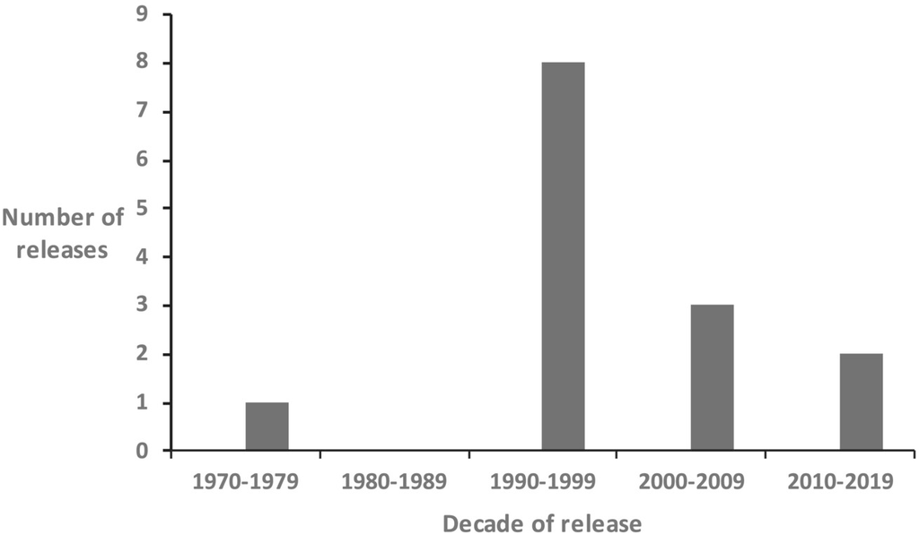

**FIGURE 2**

Releases of plant pathogens per decade for weed biological control (known deliberate releases only).

### Conflict of interest

Conflict of interest in biological control of weeds is not uncommon. Quite apart from evaluating potential non-target damage, the concept of a weed being a plant in the wrong place implies the possibility of it being sometimes in the right place and seen as valuable by some sections of the community. In the latter case, the possibility of it being reduced in abundance by a pervasive, self-perpetuating system may not always be acceptable. Australia, along with most countries practising the discipline, considered that it had a robust system for assessing the benefits and costs of undertaking a weed biological control program. For *C. juncea*, which had some grazing benefit in a few regions, resolution was relatively straightforward via discussion amongst representatives of the regions and interests involved (Cullen & Delfosse 1985). For *E. plantagineum*, however, the practised process of resolution was not accepted by people who saw the plant as beneficial, particularly beekeepers, resulting in a legal challenge in Australia's High Court in 1980. This demonstrated that the existing process of resolving conflict between opposing interests was inadequate (Cullen & Delfosse 1985). The resulting protracted legal discussions and processes made it clear that under Australian common law, a landowner could halt a national program if they could establish that it amounted to ‘unlawful interference with a person's use or enjoyment of land, or some right over it, or in connection with it’ even if only on their land. In effect, this could only be resolved by legislation, and in 1984, the Commonwealth of Australia passed the *Biological Control Act 1984* (Cullen & Delfosse 1985), which was followed over several years by mirror legislation in all state parliaments. This legislation did not require a compulsory procedure but allowed for a process of independent national assessment of the national benefit and particularly any adverse impacts of control, possibly requiring a national benefit–cost analysis, and if there is a decision to proceed, the agency has legal authority to do so by declaration under the Act. This procedure was followed for *E. plantagineum*, the benefits of national control being considered to outweigh costs by 10.5:1 (Industries Assistance Commission [IAC], 1985), and in 1985, both target and agents were declared under the Act, thus allowing the project to proceed. The *Biological Control Act* also provides a mechanism for assessing individual agents in the case of possibly controversial non-target damage and their declaration under the Act, with legal authority to release (Palmer 2013a).

In practice, the Biological Control Act has been little used due to the complex process involved and the high cost of a public inquiry and has not been legally tested in court since. It was used once again for a weed, blackberry *R. fruticosus*, and is generally recommended for all vertebrate pest biological control programs and has been used for the release of haemorrhagic disease virus against rabbits (Palmer 2013a). However, the formal, non-legal, system of regulation for considering possible conflicts of interest was improved. This now requires a target weed nomination process including broad consultation with all possible stakeholders and informed consideration of the seriousness of any conflicts raised and then submission to the relevant subcommittee of the National Biosecurity Committee, where support (without legal authority) may or may not be provided. Minor conflicts of interest can normally be resolved through this procedure, whereas more serious concerns may result in not making a nomination or withdrawal of the nomination with or without a recommendation to proceed under the relevant Biological Control Act.

### Evaluation

Despite the long recognition by researchers of the importance of adequate evaluation of the results of a biological control program, whether for demonstration of the benefits, for integration with other management approaches or to inform future practice, it has been difficult to achieve with the pressure to switch resources to new programs as soon as all releases have been made and establishment checked. Although follow-up has been more common when programs have shown early signs of success, for example, prickly pear (Dodd 1940), detailed ecological analysis has been difficult to achieve, particularly of less successful programs, given the timescale often required and resource constraints (Dhileepan 2003; Morin et al. 2009).

Nevertheless, scientists as early as the 1950s (Clark 1953a, 1953b; Clark & Clark 1952) took the opportunity to examine the interaction of the weed and agents introduced in the early program against *H. perforatum*, in considerable detail. Significant improvements have been made since the 1970s such that evaluation research has been integrated more consistently into programs where possible.

A major advance, initially developed in the *C. juncea* program, was to accept the importance of understanding the population ecology of the target weed. Wapshere et al. (1974, 1976) examined this extensively in Europe, whereas Groves and Hull (1970) looked at populations and their regional variation in Australia. This was developed further (Cullen & Groves 1978) and provided the basis for following the density declines of *C. juncea* across different regions and the impact of introduced agents (Cullen 1974, 2012), in turn enabling accurate economic evaluation of the program (Cullen 1985; Marsden et al. 1980). In the program against *S. molesta*, Room (1990) was able to model the population dynamics of the weed and the influence of other factors in its successful control (Room & Thomas 1985). This then enabled successful integration of biological control into overall management in more challenging environments (Storrs & Julien 1996; van Oosterhout et al. 2006). Briese (1991, 1997) examined more recent interactions in the *H. perforatum* system, and data from this program enabled more detailed consideration of integration with other management options (Briese 1997; Cullen et al. 1997) and careful modelling of the system (Buckley et al. 2003). The detailed evaluation of the program against *C. nutans* (Cullen & Sheppard 2012) enabled Shea et al. (2010) to model this system and to propose the optimum introduction sequence for different agents in Australia and New Zealand. The importance of knowing the ecology and population dynamics of the weed has been further emphasised by Kriticos et al. (1999), Kriticos (2003) and Briese (2004). A review by Morin et al. (2009) covered the importance of evaluation, the considerations necessary in different circumstances and the range of approaches possible, citing many Australian examples, including *E. plantagineum*, *J. vulgaris* in Tasmania, *Onopordum* spp. (van Klinken 2004), *P. hysterophorus* (Dhileepan 2007) and mesquite *Prospis* spp. (van Klinken et al. 2003). The importance of having a quantitative measure of weed performance, whether it is density, area of infestation, cover, biomass or suppression of other species, depending on the weed, together with an understanding of its relationship with agent performance, is now integral to all programs.

Methodology for monitoring agent performance was reviewed by Dhileepan (2003) and Morin et al. (2009) while noting that environmental weeds posed different questions regarding appropriate criteria against which to measure success, for example, increase in native plant species diversity. Swirepik and Smyth (2003) described an effective approach to evaluation of a program against a widespread weed, incorporating a significant number of co-operators without detailed scientific knowledge or large resources. In reviewing the discussions from a national workshop in 2002, Sheppard et al. (2003) pointed to the need to engage economists to scale up from the local to regional level and to the importance of outlining the goals at the beginning of the program and planning the evaluation approach. The end result should be a quantitative analysis, possibly incorporating modelling (Kriticos 2003), which would enable valuable economic (Nordblom 2003) and environmental evaluation of the success, even if limited, of the program. Post hoc studies, even if sometimes limited, can be valuable (Morin et al. 2009) as often illustrated by work of researchers external to a program and their students (Buckley et al. 2003; Sims-Chilton et al. 2009).

### Cost–benefit analysis and associated policy instruments

Australian weed biological programs have had a long history of evaluating the returns on the levels of investment at the program level, well before other countries with active classical biological control research portfolios. The world's first such study was a post hoc assessment of historical research and development investments in the skeleton weed biological control program carried out in 1976, based out of Montpellier and Canberra, which estimated a benefit–cost ratio (BCR) of 112:1 (Cullen 1985; Marsden et al. 1980). These returns led to enthusiasm for more consistent economic evaluation of programs, and over the next 20 years, evaluations of weed impacts, potential benefits from biological control programs or post hoc assessments of benefits were undertaken across the agricultural and, in some cases, the environmental sectors. The first fully independent assessment of the *Echium* spp. program by the Industry Assistance Commission in 1985 (IAC 1985) provided the economic basis for declaring *Echium* spp. under the *Biological Control Act 1984*. Weed biological control benefits were aggregated in a national assessment in 2006 for 36 programs where sufficient information was available (therefore excluding some known successes, e.g., *H. perforatum* and *Rumex* spp.) (Page & Lacey 2006) (see the Analysis of Success section).

### Technology and practice

Modern developments in genetic analysis for pinpointing the origin and identity of weed species and varieties were pioneered for the skeleton weed biological control program (Espiau et al. 1997). More modern technologies are now being applied to examining the stability of the host/agent relationship in the *P. chondrillina*/*C. juncea* system 49 years after the successful introduction of the first strain of *P. chondrillina* (Luo 2022), whereas reference has already been made to the importance of genetic techniques in establishing phylogeny and host-specificity test lists.

Much of modern biological control activity has been dependent on improvements in technologies of shipping and quarantine containment (Palmer 2013b), largely as a result of importing pathogens and very small arthropods, for example, eriophyid mites, plus a better appreciation of the risks associated with the importation of plant parts and soil. This has allowed a greater proportion of host-specificity testing being carried out in Australia rather than in the overseas country.

The distribution of agents and their monitoring have also become more efficient with an increased involvement of the broader community (Briese & McLaren 1997). The Australian National Landcare Program (Department of Agriculture, Water and the Environment 2022) and the development of other community groups created opportunities for interested groups to be involved in the implementation of biological control programs in the field. Resulting in part from the need to use diminishing central resources more efficiently and increased interest and education of this broader community, this has enabled the development of extensive agent establishment networks and improved evaluation across regions (Ireson et al. 2000; Jupp 1996; Swirepik et al. 2004; Swirepik & Smyth 2003).

## ANALYSIS OF SUCCESS

Based on a detailed review of all biological control programs in Australia up till 2010 (Julien et al. 2012), Cullen et al. (2013) concluded that of the 73 programs reviewed, 58 could be considered as developed programs against exotic species, and of these, 14 were rated as very successful, 11 as seasonally or regionally successful and 11 as unsuccessful. Twenty-two were considered too early in development to be assessed. Thus, of those rated, 38.9% could be considered very successful, 30.5% partially successful and 30.5% unsuccessful. The overall success rate is therefore high, and economic evaluation has put this in sharper focus.

The economic analysis of benefits from weed biological control programs in Australia (Page & Lacey 2006) concluded that 48% of programs returned some economic benefit, and the total benefit across all programs, compared with the total cost of all relevant research and development since 1904, produced an overall BCR of 23:1. With an average investment of $4.3 million a year since that time, the average annual return was $95.3 million per annum and 78% of that return was to agriculture. The ratios for individual programs vary widely, and the results for the top 10 programs are given in Table 1. Since this analysis, benefits from the *E. plantagineum* program in particular have increased significantly with steadily increasing levels of control (Invasive Plants and Animals Committee 2016). The highest ratios were obtained with widespread weeds causing significant damage and where the control was very effective, for example, *Opuntia* spp. (the highest BCR of 312:1) and *C. juncea* (BCR 112:1). However, a high BCR is possible where the weed produces limited damage, but the costs of the control program have been very small, for example, *Ambrosia artemisiifolia* L. (Page & Lacey 2006). Conversely, a successful program, such as that against *B. halimifolia*, can have a negative BCR because of the high cost. Even where success has been limited, the high costs of damage from blackberry *R. fruticosus* still produce a positive BCR of 2.5 (Page & Lacey 2006). Clearly, these kinds of assessments have not directly evaluated environmental benefits to biodiversity and ecosystem services, which are the basis of benefits for successful environmental weed biological control programs.

TABLE 1. The ten best weed biological control programs in Australia when ranked by benefit–cost ratio.

| Weed | Year commenced | Total research years | Total investment (2004/2005 $M) | Net present value ($M) | Benefit–cost ratio |
| --- | --- | --- | --- | --- | --- |
| 1. *Opuntia* spp. | 1903<sup>a</sup> | 35<sup>a</sup> | 21.1 | 3100.4 | 312.3 |
| 2. *Chondrilla juncea* | 1966 | 20–25 | 12.7 | 1412.8 | 112.1 |
| 3. *Cryptostegia grandiflora* | 1984 | 21 | 3.6 | 232.5 | 108.8 |
| 4. *Ambrosia artemisiifolia* | 1985 | 7 | 0.6 | 52.0 | 103.7 |
| 5. *Echium plantagineum* | 1972 | ~30 | 23.1 | 1178.2 | 52.0 |
| 6. *Jacobaea vulgaris* | 1929, 1977 | 29<sup>b</sup> | 7.9<sup>b</sup> | 94.2<sup>b</sup> | 32.1<sup>b</sup> |
| 7. Aquatic spp.<sup>c</sup> | 1974 | 20 | 5.1 | 76.5 | 27.5 |
| 8. *Harrisia* spp. | 1959 | 5 | 1.0 | 18.6 | 23.5 |
| 9. *Mimosa diplotricha* | 1982 | 11 | 1.7 | 20.2 | 18.0 |
| 10. *Carduus pycnocephalus* and *Carduus tenuiflorus* | 1987 | 11 | 2.1 | 20.9 | 14.1 |

- <sup>a</sup> Though the first introduction was in 1903, the main program was really only carried out from 1922 to 1935.
- <sup>b</sup> Data for 1977 program only.
- <sup>c</sup> *Salvinia molesta*, *Eichhornia crassipes* and *Pistia stratiotes* combined. The only species-specific study is for an aid program for *S. molesta* in Sri Lanka, which returned a benefit–cost ratio of 53.1.

## CONCLUSION

It could be claimed that the high BCR ratio reflects the fact that the easier targets have been tackled first and that success in the future will be more limited, but this ignores, as outlined here, the progress that has been made in the technology and methodology now available and the success against different targets and through an increasing use of pathogens as agents achieved in recent times. However, much relies on further improvements and efficiencies that can be obtained, particularly from learning from adequate follow-up studies (Morin et al. 2009) together with the recent technological advances that are now increasingly used as part of a biological control program.

The capricious nature of funding for biological control has been an ongoing source of frustration for researchers in the field. Briese (2004) discussed the societal and government issues creating increasing difficulty in obtaining support. The opportunity to study and learn from the ecological experiments carried out at large regional scale seems to have been rarely appreciated by anybody other than dedicated biological control workers. Part of the problem is that the benefits of biological control programs may continue to increase for many years after agent release, so funding that could support long-term evaluation is perceived to be better invested in starting new biological control programs. Thus, it has been extremely difficult to obtain support to carry out reasonable post hoc evaluation programs, which would help quantify the return on investment as well as test the methodology used. Without this, progress in the science will be slow and dependent on the dedication of the scientists involved.

## ACKNOWLEDGEMENTS

Rieks van Klinken made several helpful suggestions on an earlier version of the manuscript, and the comments of two unknown reviewers improved the original paper. The support of Commonwealth Scientific and Industrial Research Organisation (CSIRO) and the Department of Agriculture and Fisheries, Queensland Government, is gratefully acknowledged.

## CONFLICT OF INTEREST STATEMENT

The authors declare no conflict of interest.

## REFERENCES

[figure not shown]